## Tasks on the R datatypes

### Datatypes

**There are 5 datatypes:**

```r
# numeric (decimal, double precision)
numeric1 <- c(0.5, -0.2)
numeric1
```

```
## [1]  0.5 -0.2
```

```r
# logical (both forms acceptable)
logical1 <- c(T, FALSE)
logical1
```

```
## [1]  TRUE FALSE
```

```r
# character
character1 <- c("ABC", "d", "EF", "#$&^*")
character1
```

```
## [1] "ABC"   "d"     "EF"    "#$&^*"
```

```r
# integer
integer1 <- c(0:13)
integer1
```

```
##  [1]  0  1  2  3  4  5  6  7  8  9 10 11 12 13
```

```r
# complex
complex1 <- c(1 + 2i, 3 + 10i)
complex1
```

```
## [1] 1+ 2i 3+10i
```

> it can be converted to the specified type

```r
class(numeric1)
```

```
## [1] "numeric"
```

```r
numeric1 <- as.character(numeric1)
numeric1
```

```
## [1] "0.5"  "-0.2"
```

```r
class(numeric1)
```

```
## [1] "character"
```

> To get an integer type like **3L**

```r
x <- 3L
x
```

```
## [1] 3
```

```r
class(x)
```

```
## [1] "integer"
```

### Lists and vectors

#### *Vectors (Only one datatype)*

> If there is more than one datatype in vector, coersion occurs. It may cause > error or not.

```r
# function c() creates vector
vector1 <- c(1.2, 1.3, 1.4)
vector1
```

```
## [1] 1.2 1.3 1.4
```

> **“:”** can be used for **integer** sequence only!

```r
# ":" can be used for integer sequence only!
vector2 <- c(1:13)
vector2
```

```
##  [1]  1  2  3  4  5  6  7  8  9 10 11 12 13
```

The other way to create vector (creates empty vector):

```r
vector3 <- vector("character", length = 15)
vector3
```

```
##  [1] "" "" "" "" "" "" "" "" "" "" "" "" "" "" ""
```

#### *Lists (different datatypes within one list, list is also considered as vector)*

> Lists have elements’ indexing from 1

```r
list1 <- list(1:5, "Ef", "$#", 1.2, 1 + 4i)
list1
```

```
## [[1]]
## [1] 1 2 3 4 5
##
## [[2]]
## [1] "Ef"
##
## [[3]]
## [1] "$#"
##
## [[4]]
## [1] 1.2
##
## [[5]]
## [1] 1+4i
```

```r
list1[3]
```

```
## [[1]]
## [1] "$#"
```

### Matrices (special type of *vector*)

Empty matrix:

```r
matr1 <- matrix(nrow = 4, ncol = 4)
matr1
```

```
##      [,1] [,2] [,3] [,4]
## [1,]   NA   NA   NA   NA
## [2,]   NA   NA   NA   NA
## [3,]   NA   NA   NA   NA
## [4,]   NA   NA   NA   NA
```

```r
#matrix dimensionality
dim(matr1)
```

```
## [1] 4 4
```

```r
#attributes, dimensionality is first
attributes(matr1)
```

```
## $dim
## [1] 4 4
```

Creating filled-in matrix

```r
matr2 <- matrix(-1:14, nrow = 4, ncol = 4)
matr2
```

```
##      [,1] [,2] [,3] [,4]
## [1,]   -1    3    7   11
## [2,]    0    4    8   12
## [3,]    1    5    9   13
## [4,]    2    6   10   14
```

```r
attributes(matr2)
```

```
## $dim
## [1] 4 4
```

> Matrix can also be created from vector

```r
values <- -1:14
dim(values) <- c(4, 4)
values
```

```
##      [,1] [,2] [,3] [,4]
## [1,]   -1    3    7   11
## [2,]    0    4    8   12
## [3,]    1    5    9   13
## [4,]    2    6   10   14
```

Construct matrix by **binding**:

> **Column-binding:**

```r
col1 <- 1:10
col2 <- 11:20
col3 <- 21:30
cbind(col1, col2, col3)
```

```
##       col1 col2 col3
##  [1,]    1   11   21
##  [2,]    2   12   22
##  [3,]    3   13   23
##  [4,]    4   14   24
##  [5,]    5   15   25
##  [6,]    6   16   26
##  [7,]    7   17   27
##  [8,]    8   18   28
##  [9,]    9   19   29
## [10,]   10   20   30
```

> **Row-binding**

```r
row1 <- 1:10
row2 <- 11:20
row3 <- 21:30
rbind(col1, col2, col3)
```

```
##      [,1] [,2] [,3] [,4] [,5] [,6] [,7] [,8] [,9] [,10]
## col1    1    2    3    4    5    6    7    8    9    10
## col2   11   12   13   14   15   16   17   18   19    20
## col3   21   22   23   24   25   26   27   28   29    30
```

### Factors (to represent *categorical* data)

Vector of integers, where each *integer* has a *label* (categorical data).

```r
factor1 <- factor(c('category #1', 'category #2',  'category #1',  'category #3'))
factor1
```

```
## [1] category #1 category #2 category #1 category #3
## Levels: category #1 category #2 category #3
```

```r
# number of occurencies of each factor
table(factor1)
```

```
## factor1
## category #1 category #2 category #3
##           2           1           1
```

```r
# convert to integer representation (change attribute level)
unclass(factor1)
```

```
## [1] 1 2 1 3
## attr(,"levels")
## [1] "category #1" "category #2" "category #3"
```

> When you want to specify baseline, you can specify the first level

```r
factor2 <- factor(c('category #1', 'category #2',  'category #1',  'category #3'),
                  levels = c('category #1', 'category #2','category #3'))
factor2
```

```
## [1] category #1 category #2 category #1 category #3
## Levels: category #1 category #2 category #3
```

### Missing values (*NA* and *NaN*)

Determine if objects are **NA**:

```r
# take previously created empty (NA) matrix
is.na(matr1)
```

```
##      [,1] [,2] [,3] [,4]
## [1,] TRUE TRUE TRUE TRUE
## [2,] TRUE TRUE TRUE TRUE
## [3,] TRUE TRUE TRUE TRUE
## [4,] TRUE TRUE TRUE TRUE
```

Determine if objects are **NaN**:

```r
# the same matrix
is.nan(matr1)
```

```
##       [,1]  [,2]  [,3]  [,4]
## [1,] FALSE FALSE FALSE FALSE
## [2,] FALSE FALSE FALSE FALSE
## [3,] FALSE FALSE FALSE FALSE
## [4,] FALSE FALSE FALSE FALSE
```

> **NA** != **NaN**

### Data Frames (special list to store tabular data)

Create Data Frame:

```r
#read.table()
#read.csv()
```

> Convert Data Frame to matrix:

```r
#data.matrix()
```

```r
children <- data.frame(name = c("Sarah", "Daniel", "Connor"),
                       weight = c(5.6, 3.5, 10.4),
                       height = c(91, 80, 101))
children
```

```
##     name weight height
## 1  Sarah    5.6     91
## 2 Daniel    3.5     80
## 3 Connor   10.4    101
```

```r
nrow(children)
```

```
## [1] 3
```

```r
ncol(children)
```

```
## [1] 3
```

### Giving names to attributes

For all R objects is the same procedure

#### *Vectors’ names*

```r
# we have some sequence
sequence1 <- 1:4
# we want to assign name to the attributes of sequence
names(sequence1) <- c("one", "two", "three", "four")
# show
sequence1
```

```
##   one   two three  four
##     1     2     3     4
```

```r
# show labels only
names(sequence1)
```

```
## [1] "one"   "two"   "three" "four"
```

#### *Lists’ names*

Assigning names to each column separately:

```r
list2 <- list(a = 1:10, b = "Ef", c = "$#", d = 1 + 4i)
list2
```

```
## $a
##  [1]  1  2  3  4  5  6  7  8  9 10
##
## $b
## [1] "Ef"
##
## $c
## [1] "$#"
##
## $d
## [1] 1+4i
```

Or to the list sequence:

```r
list3 <- list(col_A = 1:3,
              col_B = 4:6)
list3
```

```
## $col_A
## [1] 1 2 3
##
## $col_B
## [1] 4 5 6
```

#### *Matrices’ names (row/col names)*

```r
matr2 <- matrix(-1:2, nrow = 2, ncol = 2)
dimnames(matr2) <- list(c("rowA", "rowB"), c("colA", "colB"))
matr2
```

```
##      colA colB
## rowA   -1    1
## rowB    0    2
```

**Datatypes in R are as follows:**

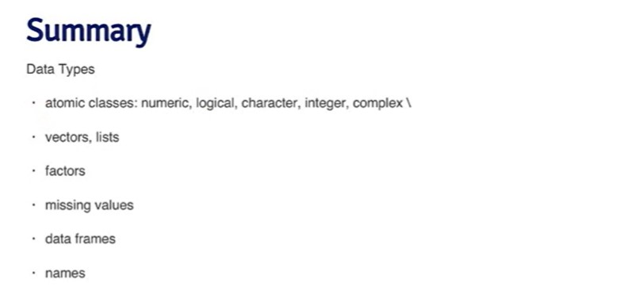

## Tasks on reading and writing data

There are following methods of reading data in R:

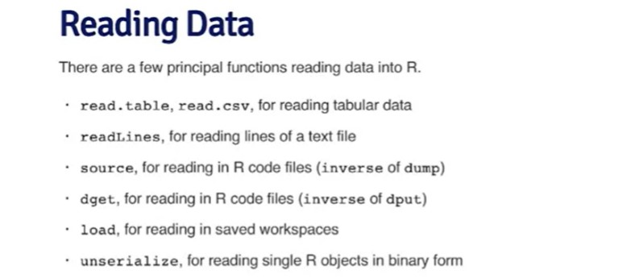

There are following methods of writing data in R:

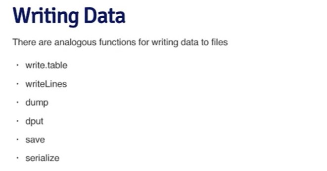

### *read.table* for small datasets

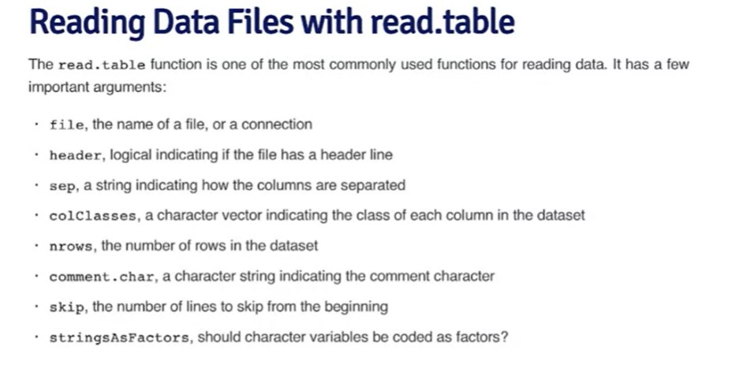

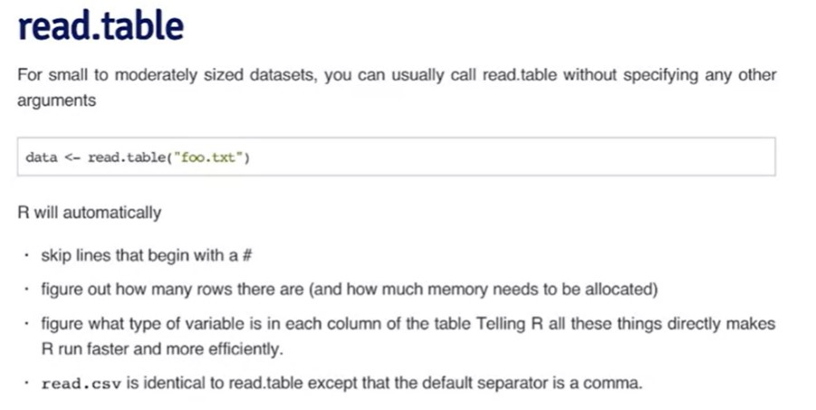

[*read.table* **documentation**](https://www.rdocumentation.org/packages/utils/versions/3.6.2/topics/read.table)

```r
data <- read.table("data/test_txt.txt",
                   header = TRUE)
data
```

```
##   col_A colB
## 1     1    2
## 2     3    4
## 3     5    6
```

### *read.table* for large datasets

> **read.table** and **read.csv** read files into the RAM of the computer!

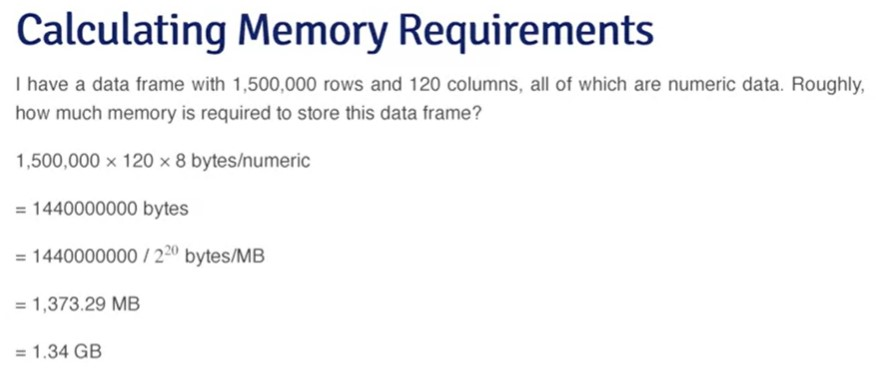

- To optimize the work, once if there are no comments in file (lines starting from **#**), set it in code **comment.char = ““**.
- There is one more good optimization practice: setting the columns types:

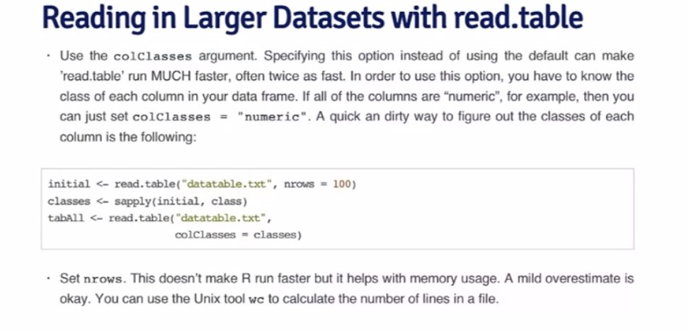

> On the picture above we can see, that called **class** function. It works faster than auto determination.

### dput() and dump()

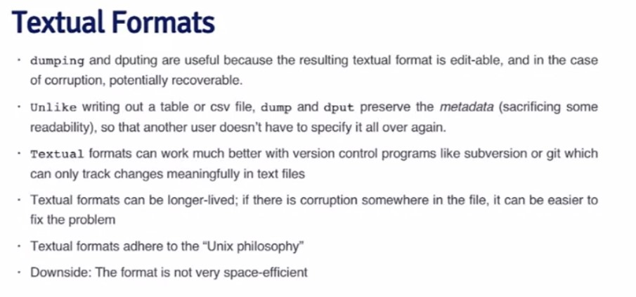

#### *dput()*

> dget can be used on single R object!

dput objects

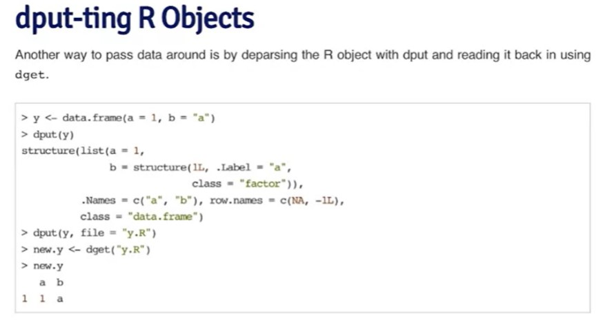

Let’s try this on the recently created DF:

```r
DF <- read.table("data/test_txt.txt",
                   header = TRUE)
dput(DF,
     file = "out/dput_DF.R")
```

read it

```r
new.DF <- dget("out/dput_DF.R")
new.DF
```

```
##   col_A colB
## 1     1    2
## 2     3    4
## 3     5    6
```

and analogically

```r
children1 <- data.frame(name = c("Sarah", "Daniel", "Connor"),
                       weight = c(5.6, 3.5, 10.4),
                       height = c(91, 80, 101))
dput(children1,
     file = "out/dput_children1.R")
new.children1 <- dget("out/dput_children1.R")
new.children1
```

```
##     name weight height
## 1  Sarah    5.6     91
## 2 Daniel    3.5     80
## 3 Connor   10.4    101
```

#### *dump()*

> dump can be used on multiple R objects!

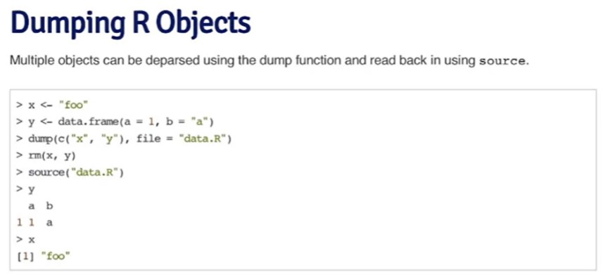

### Connection interfaces to read data

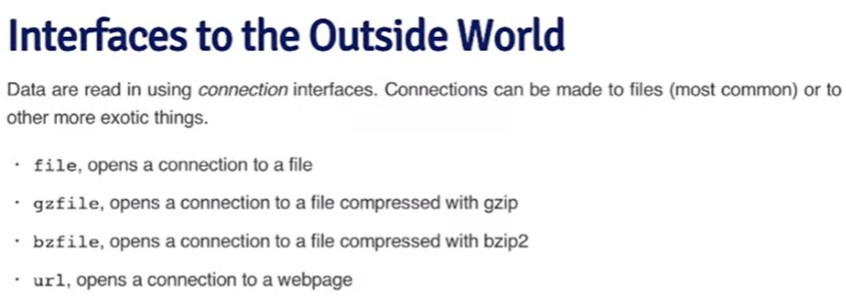

file connections:

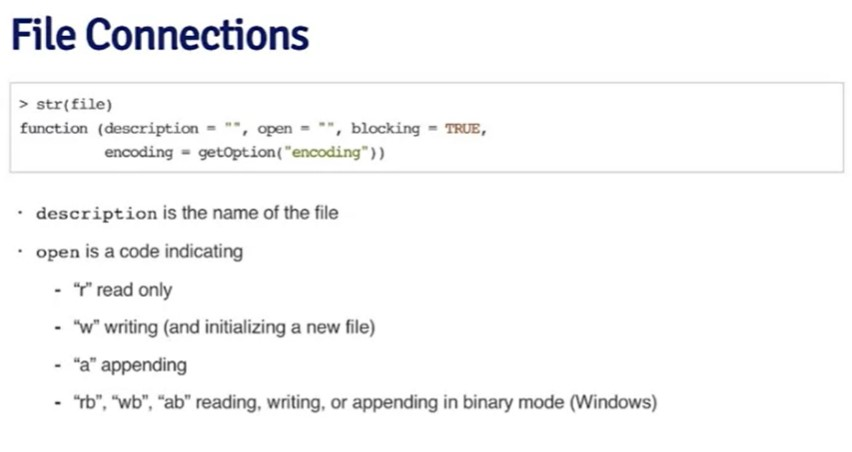

> We could open connection if it’s nedeed to read **parts** of the file.

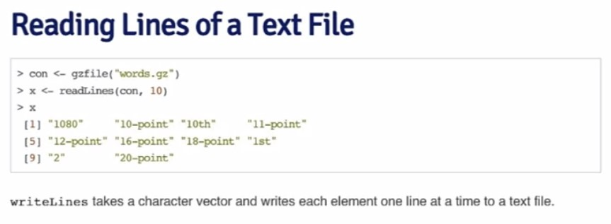

Read lines of the webpage:

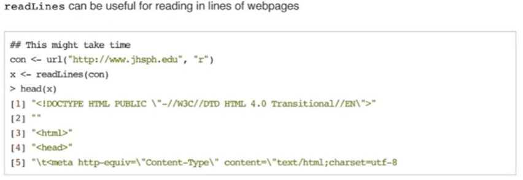

### Subsetting

Subsetting operators:

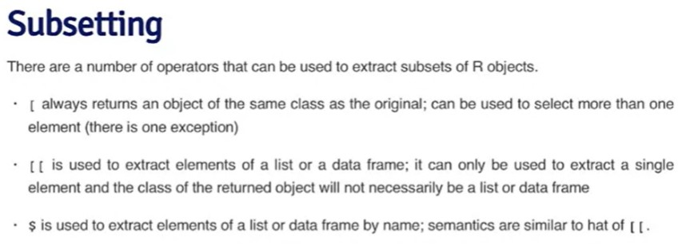

Example of numerical and logical index:

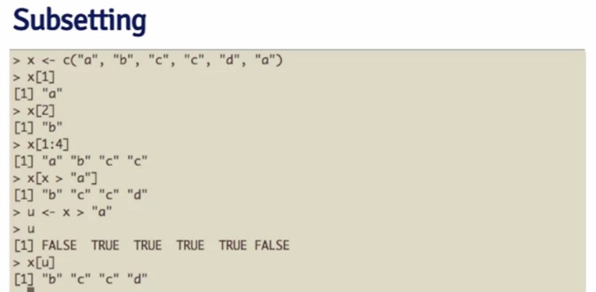

#### Subsetting lists

```r
list3 <- list(a = 1:10, b = "Efa avfs",
              c = "$#%^&6", d = 1 + 4i)
# taking by index
list3[2]
```

```
## $b
## [1] "Efa avfs"
```

```r
# take by col name
list3["a"]
```

```
## $a
##  [1]  1  2  3  4  5  6  7  8  9 10
```

```r
# taking contents of the [2]
list3[[2]]
```

```
## [1] "Efa avfs"
```

```r
#taking contents of the col
list3$a
```

```
##  [1]  1  2  3  4  5  6  7  8  9 10
```

```r
# the same as previous
list3[["a"]]
```

```
##  [1]  1  2  3  4  5  6  7  8  9 10
```

Extract *multiple* elements of the list:

```r
# provide it as a vector; get only 1 and 4
list3[c(1, 4)]
```

```
## $a
##  [1]  1  2  3  4  5  6  7  8  9 10
##
## $d
## [1] 1+4i
```

```r
# get by name
list3[c("a", "d")]
```

```
## $a
##  [1]  1  2  3  4  5  6  7  8  9 10
##
## $d
## [1] 1+4i
```

> The [[]] can be used with *computed* indices!

> The $ can be used *only* with literal names!

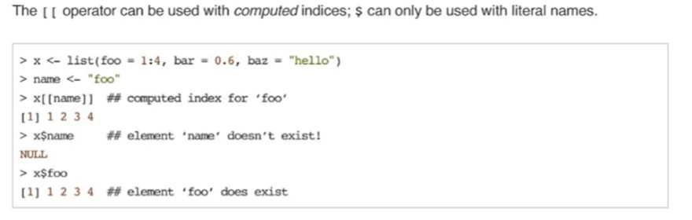

Nested elements of the list:

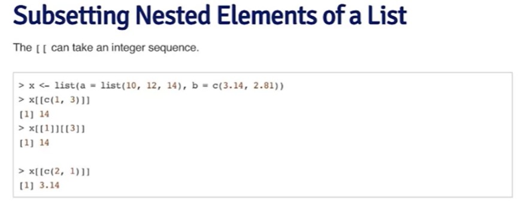

#### Subsetting matrices

```r
matr3 <- matrix(-1:2, nrow = 2, ncol = 2)
dimnames(matr3) <- list(c("rowA", "rowB"), c("colA", "colB"))
matr3
```

```
##      colA colB
## rowA   -1    1
## rowB    0    2
```

```r
# take all elements of row 2
matr3[2, ]
```

```
## colA colB
##    0    2
```

```r
# take all elements of col 2
matr3[, 2]
```

```
## rowA rowB
##    1    2
```

```r
# take element by col and row names
matr3["rowA", "colA"]
```

```
## [1] -1
```

> If it is one object returned, it returs not **matrix 1*1 **but** vector**. This can be turned off by setting** drop = FALSE** in the subsetting string.

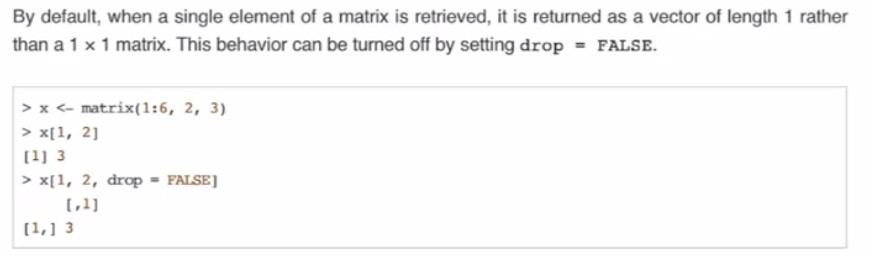

> If it is one row or column returned, it returs not **matrix** but **vector**. This can be turned off by setting **drop = FALSE** in the subsetting string as in previous example. **(x[1, , drop = FALSE])**

#### Partial matching of the names

```r
list4 <- list(a = 1:10, boo = "Efa avfs",
              c = "$#%^&6", d = 1 + 4i)
# look for the column by the name (partial)
list4$b
```

```
## [1] "Efa avfs"
```

```r
# no such col
list4[["b"]]
```

[output not shown]

```r
# look for the part
list4[["b", exact = FALSE]]
```

```
## [1] "Efa avfs"
```

#### Removing missing values

The basic practice of removing *NA* values is setting a vector of *NA* values.

```r
vector_na <- c(1, 3, NA, 4, 1, NA, NA)
# logical vector, that defines NA
na <- is.na(vector_na)
# without na
vector_na[!na]
```

```
## [1] 1 3 4 1
```

There is other practice: showing non NA elements only:

```r
# taking two vectors
vector_na <- c(1, 3, NA, 4, 1, NA, NA)
vector_na2 <- c(1, NaN, NA, -1, 4, 2, NaN)
#using function of getting no NA
good_cases <- complete.cases(vector_na, vector_na2)
vector_na[good_cases]
```

```
## [1] 1 4 1
```

```r
print("other:")
```

```
## [1] "other:"
```

```r
vector_na2[good_cases]
```

```
## [1]  1 -1  4
```

> **complete.cases** igrores both *NA* and *NaN*!

**complete.cases** can be also used with *Data Frames*:

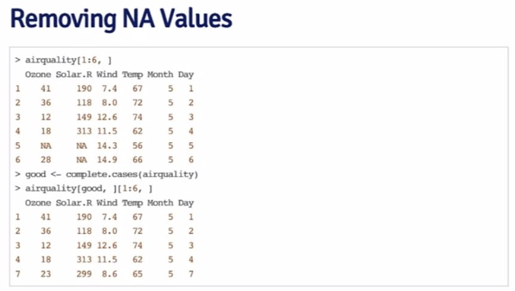

> **complete.cases** removes *all the row* with at least one *NA/NaN*

### Vectorized operations

The main idea is in making *parallel* to that more *efficient* operations.

> There is no loop needed!

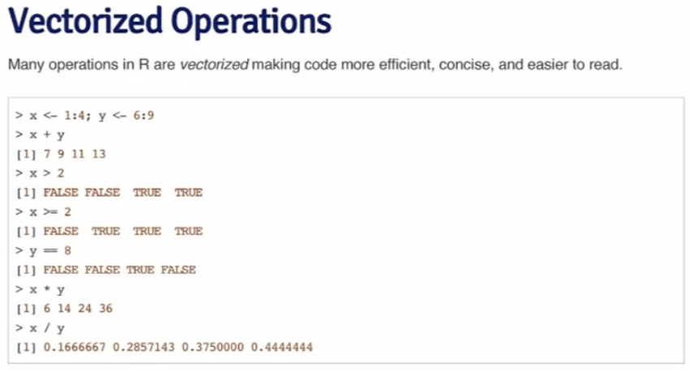

#### Vectorized matrix operations

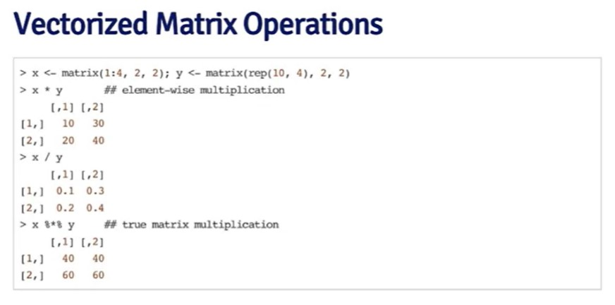